# R Notebook

```r
library(tidyverse)
library(janitor)
library(mosaicData)
library(mosaic)
library(GGally)
```

|  | hightemp | lowtemp | avgtemp | spring | summer | fall | cloudcover | precip | volume | weekday | dayType |
| --- | --- | --- | --- | --- | --- | --- | --- | --- | --- | --- | --- |
| 1 | 83 | 50 | 66.5 | 0 | 1 | 0 | 7.6 | 0.00 | 501 | TRUE | weekday |
| 2 | 73 | 49 | 61.0 | 0 | 1 | 0 | 6.3 | 0.29 | 419 | TRUE | weekday |
| 3 | 74 | 52 | 63.0 | 1 | 0 | 0 | 7.5 | 0.32 | 397 | TRUE | weekday |
| 4 | 95 | 61 | 78.0 | 0 | 1 | 0 | 2.6 | 0.00 | 385 | FALSE | weekend |
| 5 | 44 | 52 | 48.0 | 1 | 0 | 0 | 10.0 | 0.14 | 200 | TRUE | weekday |
| 6 | 69 | 54 | 61.5 | 1 | 0 | 0 | 6.6 | 0.02 | 375 | TRUE | weekday |

# Cleaning

```r
railtrail_clean <- RailTrail %>%
  clean_names() %>%
    mutate(
      spring = ifelse(spring == 1, TRUE, FALSE),
      summer = ifelse(summer == 1, TRUE, FALSE),
      fall = ifelse(fall == 1, TRUE, FALSE)
  )
```

# Redundant Predictors

Variables which can be predicted from, or are aliases of, other variables. If we leave these in we will have multicolinearity and our model will account for these variables repeatedly.

```r
alias(lm(volume ~ ., data = railtrail_clean))
```

```
Model :
volume ~ hightemp + lowtemp + avgtemp + spring + summer + fall +
    cloudcover + precip + weekday + day_type

Complete :
                (Intercept) hightemp lowtemp springTRUE summerTRUE cloudcover precip
avgtemp           0         1/2      1/2       0          0          0          0
fallTRUE          1           0        0      -1         -1          0          0
day_typeweekend   1           0        0       0          0          0          0
                weekdayTRUE
avgtemp           0
fallTRUE          0
day_typeweekend  -1
```

# GGpairs

examine plots to find predictors which appear to be associated with volume. The outcome variable for our model.

[figure not shown]

```r
ggpairs(railtrail_clean)
```

This shows some correlation between volume and average temperature. So we can start building a model with the hypothesis that volume increases as avg_temp increases.

# Linear Regression Model

response variable: volume predictor variable: avgtemp

volume = intercept + b(avg_temp) * avgtemp

## Plot lm model

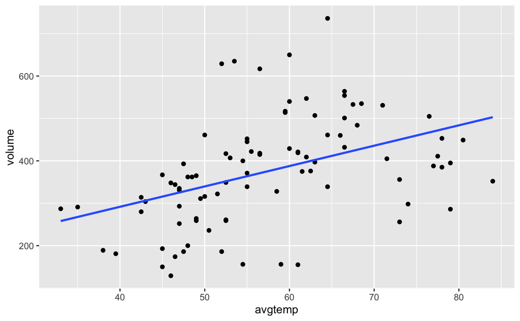

## Build simple linear regression model

## Check Goodness of Fit

[output not shown]

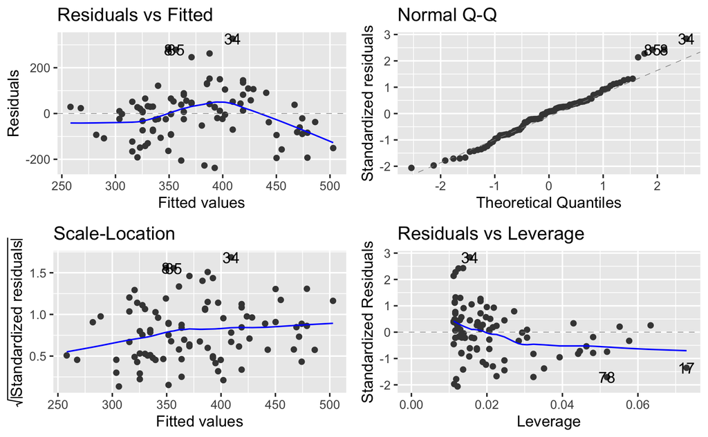

```r
autoplot(model)
```

```r
summary(model)
```

```
Call:
lm(formula = volume ~ avgtemp, data = railtrail_clean)

Residuals:
    Min      1Q  Median      3Q     Max
-237.53  -80.00    8.49   55.14  326.67

Coefficients:
            Estimate Std. Error t value Pr(>|t|)
(Intercept)   99.602     63.474   1.569     0.12
avgtemp        4.802      1.084   4.428 2.72e-05 ***
---
Signif. codes:  0 ‘***’ 0.001 ‘**’ 0.01 ‘*’ 0.05 ‘.’ 0.1 ‘ ’ 1

Residual standard error: 115.9 on 88 degrees of freedom
Multiple R-squared:  0.1822,    Adjusted R-squared:  0.1729
F-statistic: 19.61 on 1 and 88 DF,  p-value: 2.723e-05
```

# A parralel slopes model.

e.g. Add predictors to the model

## Find and check a variables significance to the output

We hypothesise that weekday has an effect on volume

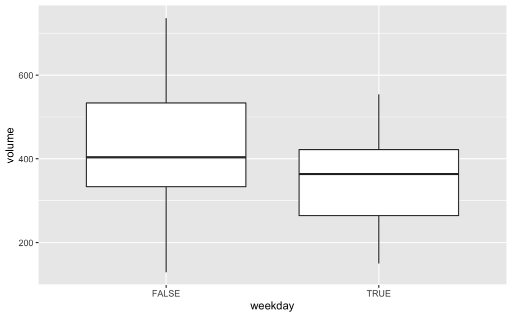

Difference in numbers.

| cor |
| --- |
| -0.2932675 |

A weak negative correlation.

# Adding a categorical variable

## Check effectiveness

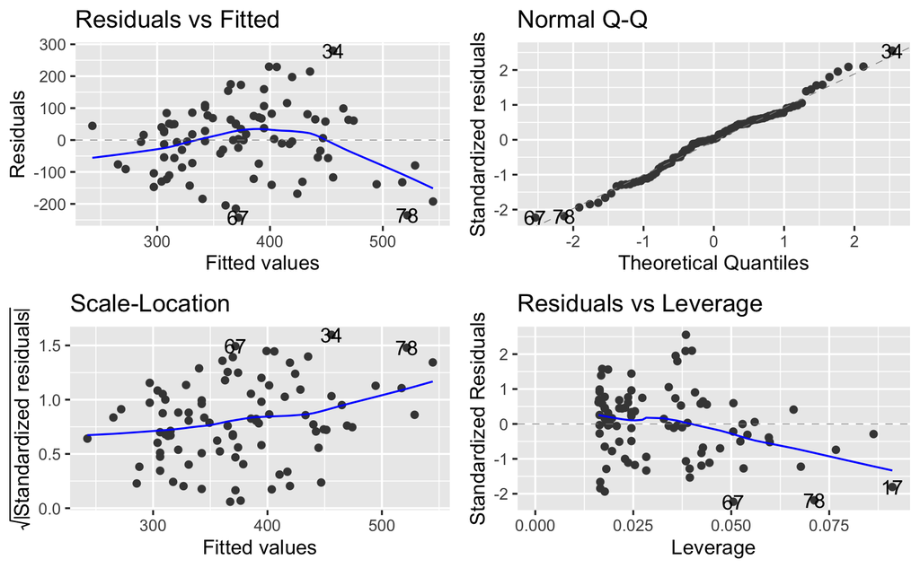

```r
summary(model2)
```

```
Call:
lm(formula = volume ~ avgtemp + weekday, data = railtrail_clean)

Residuals:
    Min      1Q  Median      3Q     Max
-242.92  -75.72    3.15   66.90  280.06

Coefficients:
            Estimate Std. Error t value Pr(>|t|)
(Intercept)  163.022     65.428   2.492  0.01461 *
avgtemp        4.541      1.050   4.323 4.08e-05 ***
weekdayTRUE  -70.320     25.566  -2.751  0.00724 **
---
Signif. codes:  0 ‘***’ 0.001 ‘**’ 0.01 ‘*’ 0.05 ‘.’ 0.1 ‘ ’ 1

Residual standard error: 111.8 on 87 degrees of freedom
Multiple R-squared:  0.2476,    Adjusted R-squared:  0.2303
F-statistic: 14.32 on 2 and 87 DF,  p-value: 4.214e-06
```

r^2 has improved from 0.18 to 0.25. WeekdayTRUE coefficient -70, means that every day which is a weekday we should see 70 less people visiting. Pr(>|t|) = the p value for this test indicates that it is statistically significant. avgtemp coefficient 4.5 means for each unit of temperature increase, we expect 4.5 more visitors.

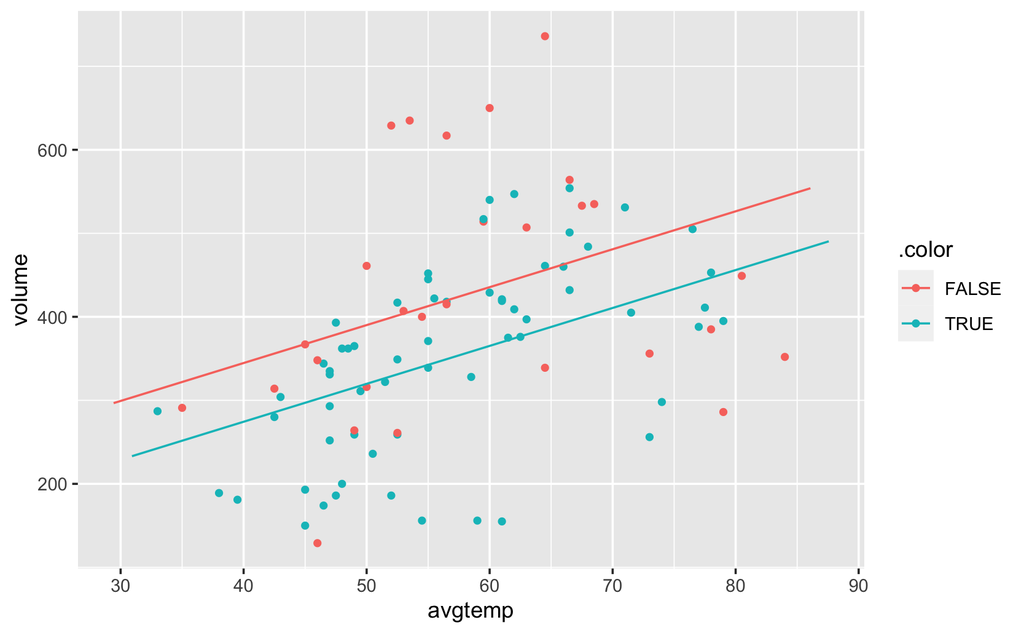

In a parallel slopes model, the only difference in calculating the line is the intercept. The lines are parallel.

# Interactions

Why do we need them?

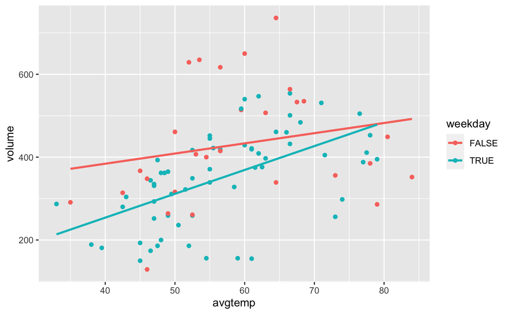

avgtemp affects the volume differently depending on whether it is a weekday or not.

## Add interaction to the model

## Plot new model

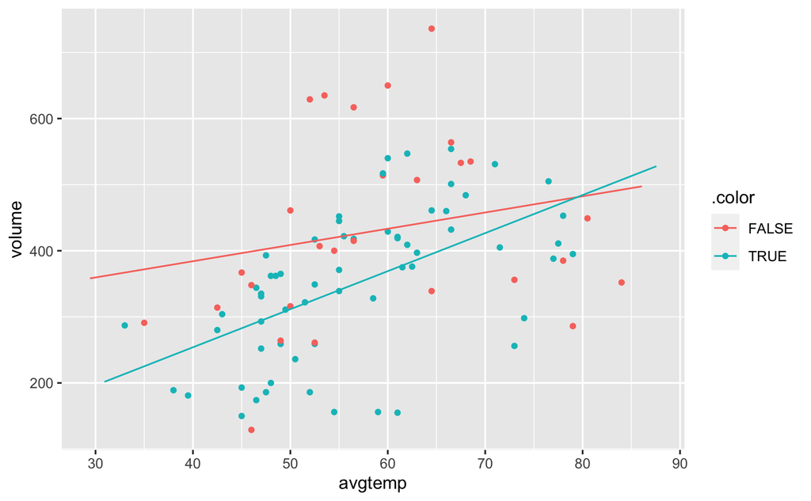

## Check whether the addition is justified.

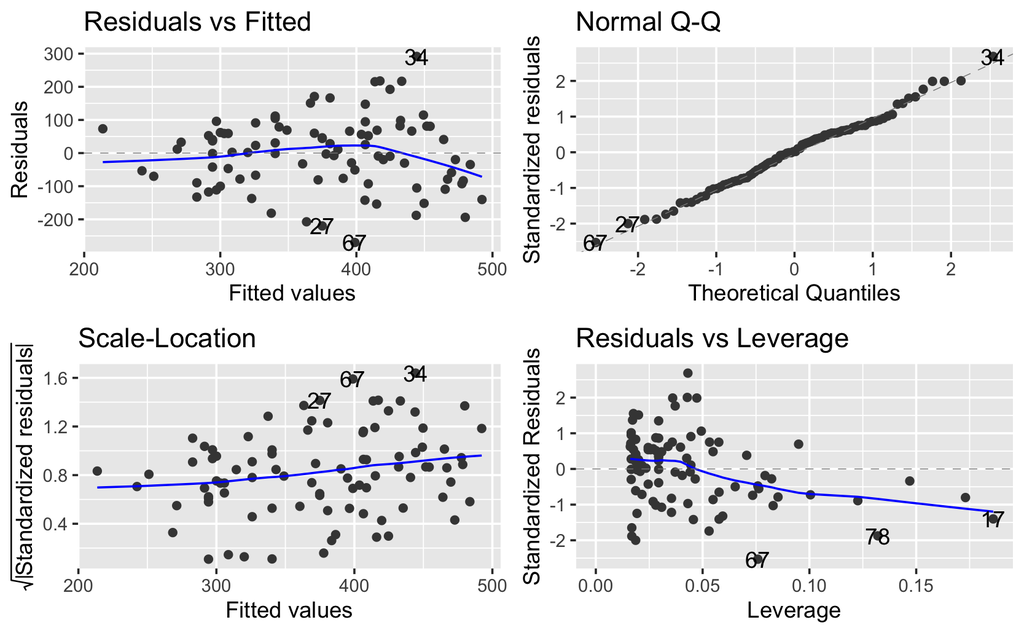

```r
summary(model4)
```

```
Call:
lm(formula = volume ~ avgtemp + weekday + avgtemp:weekday, data = railtrail_clean)

Residuals:
     Min       1Q   Median       3Q      Max
-269.906  -78.862    2.064   68.190  291.641

Coefficients:
                    Estimate Std. Error t value Pr(>|t|)
(Intercept)          285.887    103.390   2.765  0.00696 **
avgtemp                2.457      1.718   1.431  0.15619
weekdayTRUE         -262.193    128.181  -2.045  0.04386 *
avgtemp:weekdayTRUE    3.300      2.161   1.527  0.13040
---
Signif. codes:  0 ‘***’ 0.001 ‘**’ 0.01 ‘*’ 0.05 ‘.’ 0.1 ‘ ’ 1

Residual standard error: 111 on 86 degrees of freedom
Multiple R-squared:  0.2675,    Adjusted R-squared:  0.2419
F-statistic: 10.47 on 3 and 86 DF,  p-value: 6.115e-06
```

# Adding a continuous variable

## Are cloudcover and volume associated?

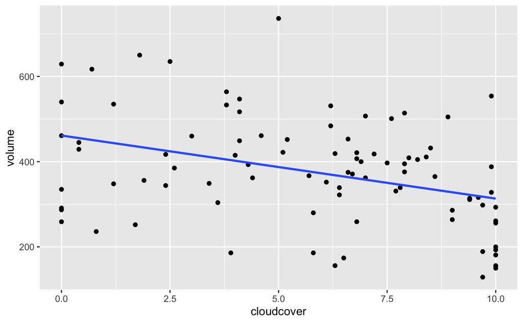

## Add to model

```r
summary(model5)
```

```
Call:
lm(formula = volume ~ avgtemp + weekday + cloudcover, data = railtrail_clean)

Residuals:
     Min       1Q   Median       3Q      Max
-204.803  -58.375    6.594   60.178  277.581

Coefficients:
            Estimate Std. Error t value Pr(>|t|)
(Intercept) 200.1022    59.1826   3.381  0.00109 **
avgtemp       5.2461     0.9536   5.502 3.81e-07 ***
weekdayTRUE -47.9480    23.4061  -2.049  0.04356 *
cloudcover  -16.0115     3.3952  -4.716 9.21e-06 ***
---
Signif. codes:  0 ‘***’ 0.001 ‘**’ 0.01 ‘*’ 0.05 ‘.’ 0.1 ‘ ’ 1

Residual standard error: 100.3 on 86 degrees of freedom
Multiple R-squared:  0.4022,    Adjusted R-squared:  0.3814
F-statistic: 19.29 on 3 and 86 DF,  p-value: 1.185e-09
```

R^2 increases to 0.4 Residual standard error drops by 11 to 100.3

## Plotting this model

Things get complicated. You could explore plotly package to draw 3D plots.

# Interaction with continuous predictors

We hypothesise that the relationship between avgtemp and precip will affect volume. e.g. a hot wet day will discourage users

# Check significance of interactions

Coplot, shingles plot or rooftiles plot

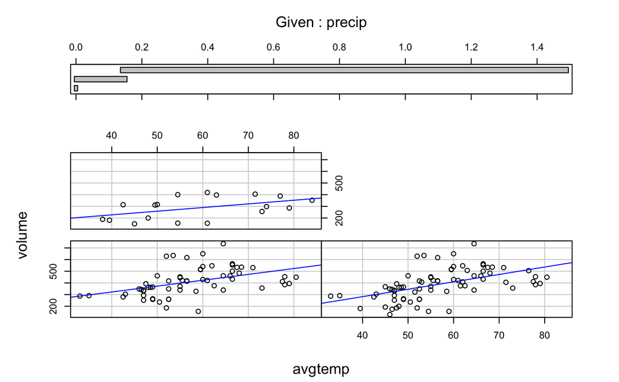

```r
# plot volume against avgtemp, conditional on precip
# volume versus avgtemp given precip
coplot(volume ~ avgtemp | precip,
       # add line of best fit
       panel = function(x, y, ...) {
         points(x,y)
         abline(lm(y ~ x), col = "blue")
       },
       # set how much the precip shingles overlap
       overlap = 0.2,
       data = railtrail_clean)
```

This example is of a coplot where the interaction does not have a significant impact. If the slope of the lines varied for each shingle, this would indicate a potentially significant interaction between the predictor on the x axis and the conditional predictor.

- the bottom left scatter plot corresponds to volume versus avgtemp for precip values in a narrow range from 0 inches to approximately 0.01 inches (i.e. essentially the days where it did not rain).
- the bottom right scatter plot corresponds to volume versus avgtemp for precip values in a broader range from 0 inches to approximately 0.16 inches.
- the top left scatter plot corresponds to volume versus avgtemp for precip values in a very broad range from approximately 0.14 inches to approximately 1.5 inches. Why have the shingles ended up being the width that they are? R tries to arrange the shingles so that, as far as possible, they contain near equal numbers of data points.

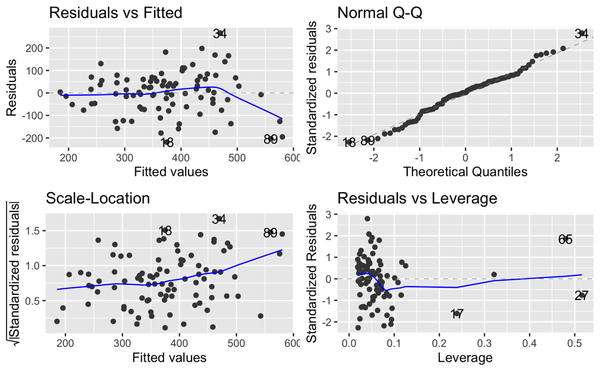

```r
summary(model7)
```

```
Call:
lm(formula = volume ~ avgtemp + cloudcover + weekday + precip +
    avgtemp:precip, data = railtrail_clean)

Residuals:
     Min       1Q   Median       3Q      Max
-218.775  -59.164    3.183   57.361  266.189

Coefficients:
                Estimate Std. Error t value Pr(>|t|)
(Intercept)     153.9280    63.9007   2.409 0.018189 *
avgtemp           5.8964     1.0598   5.564 3.08e-07 ***
cloudcover      -12.8866     3.6984  -3.484 0.000786 ***
weekdayTRUE     -45.8527    22.7365  -2.017 0.046921 *
precip         -100.8213   353.3547  -0.285 0.776097
avgtemp:precip   -0.2335     4.8893  -0.048 0.962023
---
Signif. codes:  0 ‘***’ 0.001 ‘**’ 0.01 ‘*’ 0.05 ‘.’ 0.1 ‘ ’ 1

Residual standard error: 97.29 on 84 degrees of freedom
Multiple R-squared:  0.4501,    Adjusted R-squared:  0.4173
F-statistic: 13.75 on 5 and 84 DF,  p-value: 8.34e-10
```

This addition is not justified. without avgtemp:precip, precip gets a p value of 0.008, adding the avgtemp:precip is not statistically significant and it nullifies the effect of precip on the model.